# Lesson 4B: Examining Numerical Variables

DS 01-101: In-Depth Introduction to Data Science (Spring 2026)

Author

Affiliation

Hung Tong

Rowan University

## Basic Data Types

- Recall that a variable can be **numerical** or **categorical**.

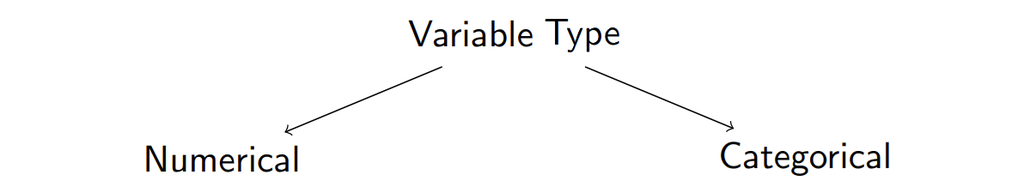

- A **numerical variable** represents numbers that are meaningful to add, subtract, or take averages.
- A **categorical variable** refers to specific categories that describe a characteristic.

## Histogram

- **Histogram** is like a *bar plot* for numerical data, but there is no separation between the bars. Numbers are divided into bins and the frequency distribution of these bins is displayed.
- From a histogram, we can learn about the data distribution
  - **Shape:** Is it symmetric, left-skewed, or right-skewed? Is it unimodal or multimodal? How many peaks?
  - **Typical Value:** Where do most data values seem to concentrate?
  - **Spread:** What is the approximate range of the data? How far are data points from the typical value?
- In a **symmetric** distribution, the left tail approximately mirrors the right tail.

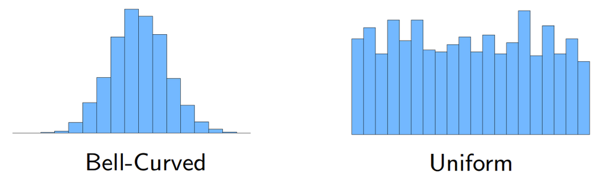

- A data distribution is said to be **left-skewed** if its tail extends further to the left.
  - *Example:* age of retirement, lifetime.
- A distribution is said to be **right-skewed** if its tail extends further to the right.
  - *Example:* housing prices, salaries.
- Note that **skewness** is about the skinny tail

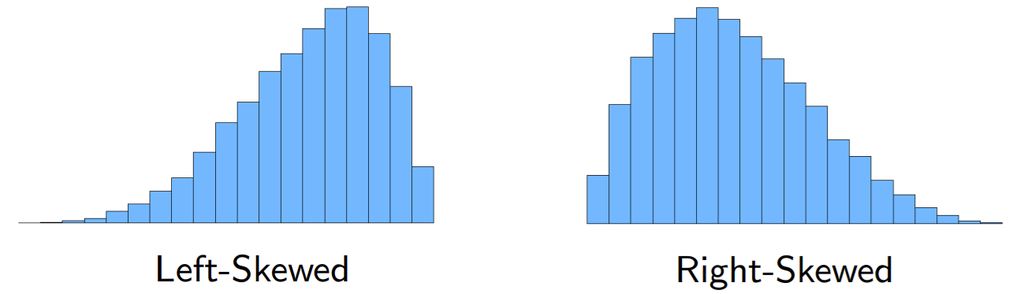

- Previous distributions with only one peak are called **unimodal**.
- A distribution with exactly two peaks is called **bimodal**.

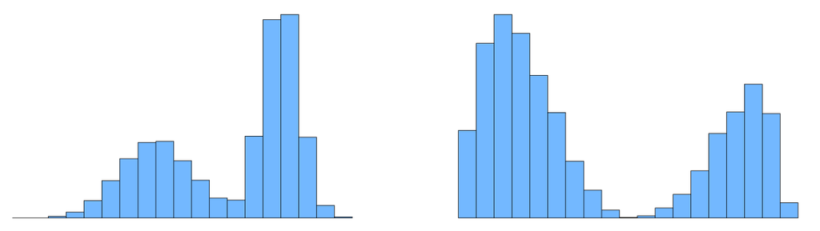

- When a distribution has more than one peak, it is called **multimodal**.

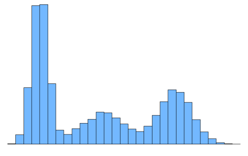

## Histogram in R

- Histogram can be generated using the `hist()` function. The number of bins will be automatically determined by R, but we can also adjust by changing `breaks`.
- Recall Common graphical parameters in base R plotting:
  - `col` - add color to the plot
  - `main` - main title label
  - `xlab` - label for x-axis
  - `ylab` - label for y-axis
  - `xlim` - x-axis range
  - `ylim` - y-axis range
  - `cex.main` - size of main title
  - `cex.lab` - size of axis labels
  - `cex.axis` - size of tick labels

**Hands-On**

The `bus_driver` data set was collected from bus drivers employed by public corporations. Each data point gives the number of traffic accidents in which each bus driver was involved during a 4-year period. Obtain the histogram of this data set and comment on the data distribution.

```r
# load("l4b_data.rdata")
```

**Answer:**

```r
### R code here
```

**Hands-On**

The `math_sat` data set contains the math-portion scores of the SAT exam in 2008. Each score is between 200 and 800. Obtain the histogram of this data set and comment on the data distribution.

```r
# load("l4b_data.rdata")
```

**Answer:**

```r
### R code here
```

**Hands-On**

The `lifetime` data set contains ages at death for a group of individuals. Obtain the histogram of this data set and comment on the data distribution.

```r
# load("l4b_data.rdata")
```

**Answer:**

```r
### R code here
```

## Mean and median

- When describing numerical data, it is common to report **representative** value(s), where **representative** implies that the data tend to be centered or located around these particular value.
- When the data distribution is unimodal, common measures to describe the data are:
  - Mean
  - Median
  - Mode (more useful for categorical data)
- The **mean** is the average value of the data. Every observation has an equal contribution to the calculation of the mean, i.e., center of “mass.”

$$\bar{x} = \dfrac{x_1 + x_2 + \dots + x_n}{n}$$

- The **median** is the middle value when the data are arranged in ascending order. It is also known as the $50$th percentile or the second quartile $Q_2$.
- The median divides the data into two parts: approximately half ($50\%$) less than the median and approximately the other half ($50\%$) greater than the median.

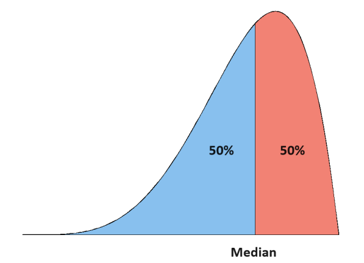

- Calculating the mean is relatively straightforward, while calculating the median requires sorting the data. However, the mean is easily influenced by skewness and outliers compared to the median.

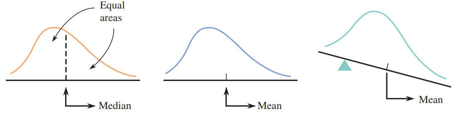

- When the data distribution is multimodal, the mean and median of each sub-population should be reported instead.

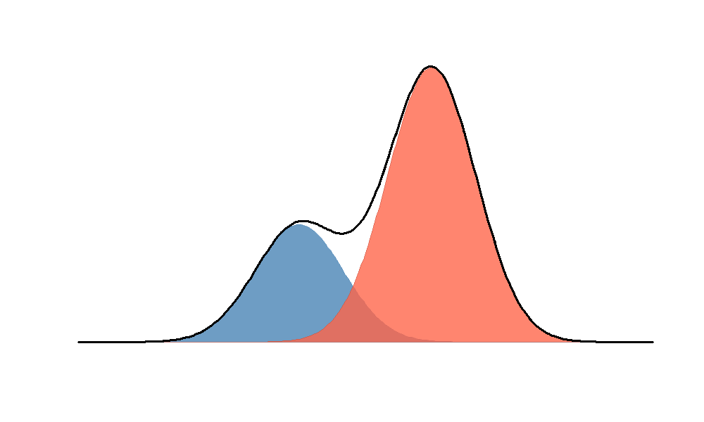

## Quartiles and five-number summary

- **Quartiles** are 3 specific percentiles that divide a dataset into four parts, with each part containing approximately one-fourth, or $25\%$, of the observations.
  - $Q_1$ - First quartile or $25$th percentile
  - $Q_2$ - Second quartile or $50$th percentile or the **median**
  - $Q_3$ - Third quartile or $75$th percentile

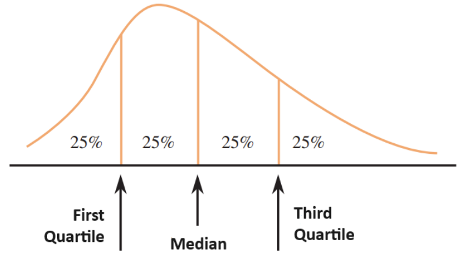

- Quartiles are robust to skewness and outliers.
- A **five-number summary** refers to the following $5$ numbers to summarize the data
  1. Minimum (smallest value)
  2. $Q_1$ - First quartile or $25$th percentile
  3. $Q_2$ - Second quartile or $50$th percentile or the **median**
  4. $Q_3$ - Third quartile or $75$th percentile
  5. Maximum (largest value)

## Variance and standard deviation

- Variability is also known as spread. Variability refers to how much the data values are spread out.
  - Interquartile range (IQR)
  - Variance
  - Standard deviation
- The **interquartile range (IQR)** is the difference between the third and first quartiles.
- The **variance** is a measure of variability that aims to quantify how much the data values are spread from the mean. The units associated with the variance are squared and the variance must be positive.

$$s^2 = \dfrac{\sum_{i = 1}^n (x_i - \bar{x})^2}{n - 1}$$

- The **standard deviation** is defined to be the positive square root of the variance.

$$s = \sqrt{s^2}$$

- Unlike the variance, the standard deviation is measured in the same units as the data, which is easier to interpret. The standard deviation must also be positive.
- The standard deviation roughly describes how far away typical observations are from the mean.

## Summary statistics in R

Summary statistics for a data set can be obtained as follows:

- `mean()` gives the sample mean
- `median()` gives the sample median
- `min()` gives the minimum value
- `max()` gives the maximum value
- `range()` gives a vector containing the minimum and maximum
- `summary()` gives the five-number summary and sample mean
- `IQR()` gives the interquartile range
- `var()` gives the sample variance
- `sd()` gives the sample standard deviation

**Hands-On**

Find summary statistics of the `bus_driver`, `math_sat`, and `lifetime` data sets.

```r
# load("l4b_data.rdata")
```

**Answer:**

```r
### R code here
```

## Box plot

- **Box plot** is a graphical display of the data based on a five-number summary.
- From a box plot, we can learn about the data distribution
  - **Typical Value:** The median
  - **Spread:** The range and interquartile range (IQR) of the data. The larger the interquartile range (IQR), the higher variability in the data
  - **Outliers:** Potential outliers are marked automatically

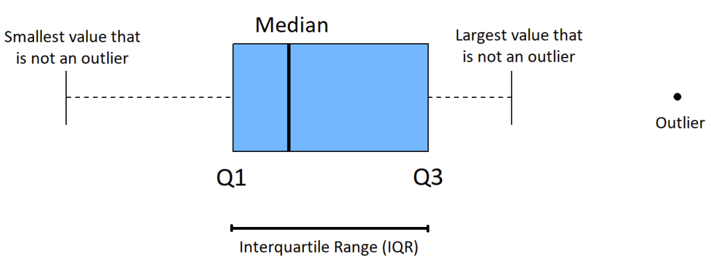

- Box plot and histogram should both be made to complement each other.
- Side-by-side box plots are used to compare the distribution of a numerical variable across different categories.

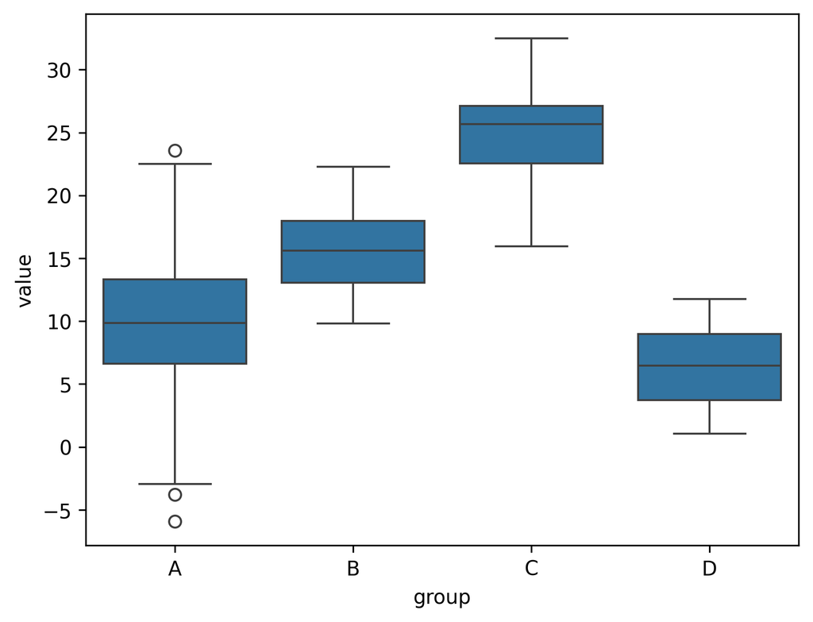

## Box plot in R

**Hands-On**

Obtain the box plots of the `bus_driver`, `math_sat`, and `lifetime` data sets.

```r
# load("l4b_data.rdata")
```

**Answer:**

```r
### R code here
```

## Scatter plot and correlation

- **Scatter plot** provides a view of the relationship between two numerical variables. One may be considered as the **explanatory variable** and the other one as the **response**.

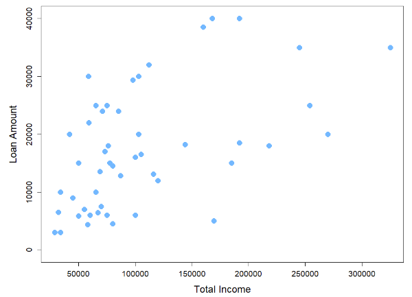

- Different colors or point symbols can be used on a scatter plot to incorporate information from a categorical variable

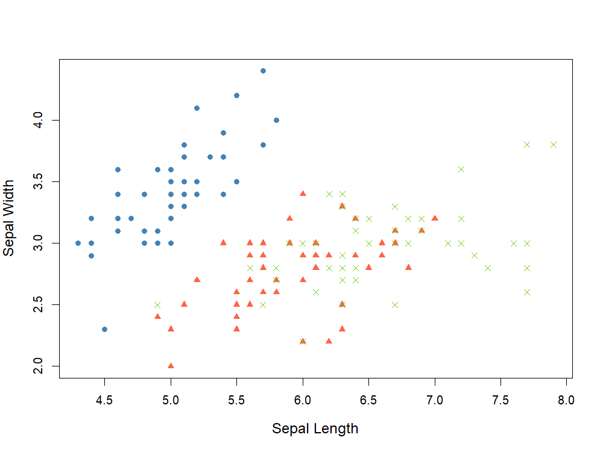

- A **linear relationship** refers to one that can be approximated by a straight line on a scatter plot.

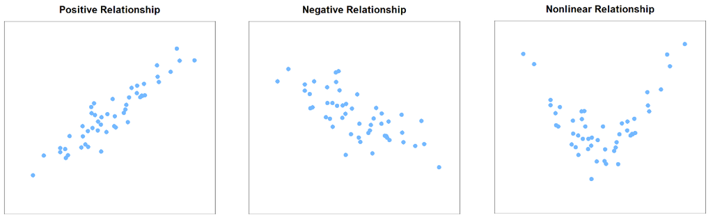

- **Correlation** is a measure to quantify the strength of the linear relationship between two numerical variables. Correlation does not depend on the units of measurement.
- Correlation is strictly between $-1$ and $1$.
  - The closer to $1$, the stronger the **positive** linear relationship is.
  - The closer to $-1$, the stronger the **negative** linear relationship is.

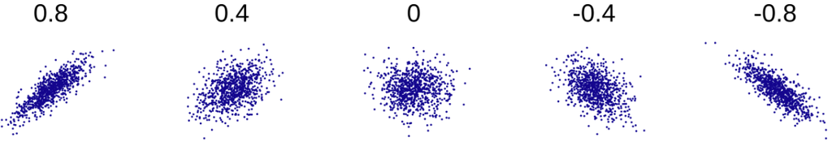

## Scatter plot in R

- Scatter plot can be generated using the `plot()` or `pairs()` function.
- Useful graphical parameters include
  - `cex` - adjust the size of data points
  - `pch` - plotting character (point symbol)

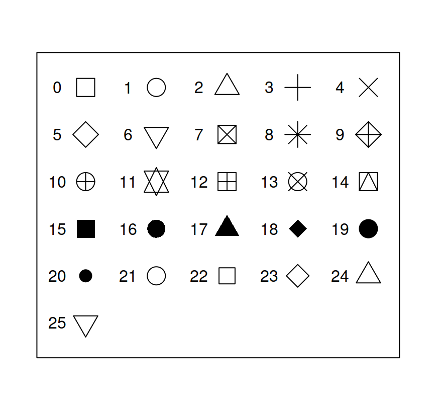

**Hands-On**

The `cars` data set gives `speed` in mph and stopping distance `dist` in ft of cars in 1920s. Obtain the correlation and scatter plot of `speed` and `dist`

**Answer:**

```r
### R code here
```

**Hands-On**

The `USArrest` data set contains crime statistics for assault, murder, and rape in each of the 50 US states in 1973. It also contain the percent of the population living in urban areas.

**Answer:**

```r
### R code here
```

## Behavioral survey from the Centers for Disease Control and Prevention (CDC)

The data set is slightly modified from [OpenIntro](https://www.openintro.org/book/statdata/?data=cdc),

> The Behavioral Risk Factor Surveillance System (BRFSS) is an annual telephone survey of 350,000 people in the United States collected by the Centers for Disease Control and Prevention (CDC). As its name implies, the BRFSS is designed to identify risk factors in the adult population and report emerging health trends. For example, respondents are asked about their diet and weekly physical activity, their HIV/AIDS status, possible tobacco use, and even their level of healthcare coverage. The [BRFSS Web site](https://www.openintro.org/redirect.php?go=cdc_data_brfss&referrer=data_set_page) contains a complete description of the survey, the questions that were asked and even research results that have been derived from the data.

> This data set is a random sample of 20,000 people from the BRFSS survey conducted in 2000. While there are over 200 questions or variables in this dataset, this data set only includes 9 variables.

The data set has the following variables:

- `genhlth` - General health, with categories Excellent, Very Good, Good, Fair, and Poor
- `exerany` - Whether the respondent exercised in the past month
- `hlthplan` - Whether respondent has some form of health coverage
- `smoke100` - Whether respondent has smoked at least 100 cigarettes in their entire life
- `height` - Respondent’s height in inches
- `weight` - Respondent’s weight in pounds
- `wtdesire` - Respondent’s desired weight in pounds
- `age` - Respondent’s age in years
- `gender` - Respondent’s gender